# New Product Sales Methods Analysis

## About the Project

Six weeks ago, we launched a new line of office stationery, and we tested three different sales strategies - targeted email, phone calls, and a combination of both.

## Business Goals

As these methods vary in their demand on the team's time, our business goal was to determine the differences between them and to identify the most effective sales approach that we should continue using.

This report provides an analysis of the given data and presents my thoughts on choosing a sales method. It summarizes the results obtained from the analysis and provides recommendations for the company.

## Data validation

The dataset contains **15000 rows and 8 columns** before cleaning and validataion. I have validated all the columns against the criteria in the dataset table:

- **week:** Weeks from 1 to 6, as expected. No cleaning is needed.
- **sales_method:** There were different versions of methods' names. I standartized them to 'call', 'email' and 'email + call'.
- **customer_id:** 15000 unique values. No cleaning is needed.
- **nb_sold:** 10 unique values between 7 and 16. No cleaning is needed.
- **revenue:** There are 1074 missing values in the dataset. I have considered two potential approaches to handle this data. Since it accounts for 7% of all data, one option is to replace the missing values with the median for each method. However, this could potentially affect the distribution of revenue. Another approach is to remove the rows with missing data. Although it involves removing a significant amount of data, I am unsure why there are missing values in the revenue column. I didn't find any patterns so it's **Missing Completely at Random** data. It could be due to uncompleted transactions or returns, and so removing those rows may be a better option. So I removed those rows, leaving 13926 rows of data.
- **years_as_customer:** I removed rows where the number of years as customer was bigger then number of years company existed. This was 2 rows, leaving 13924 rows of data.
- **nb_site_visits:** 27 unique values between 12 and 41. No cleaning is needed.
- **state:** 50 unique names of states. No cleaning is needed.

After the data validation, the dataset contains **13924 rows and 8 columns** without missing values.

## What differences are there between the sales method groups?

During the six weeks since the launch of the new product, the **email** approach had the highest number of customers, approximately **50%**, with 6921 customers. The **call** approach had 4780 customers, representing **34%** of all customers during this time period. Lastly, the approach involving both **email and call** had about **16%** or 2223 customers.

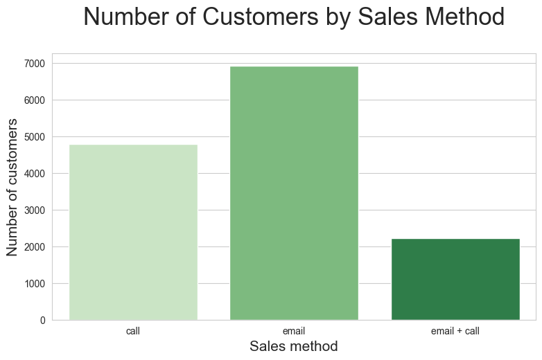

We intend to examine the revenue distribution of all products sold during the previous 6 weeks. The revenue is distributed such that most products sold generate less than `190$`, and those that exceed this value could be considered as outliers. The **median revenue** value for all products sold is **`89,5$`**.

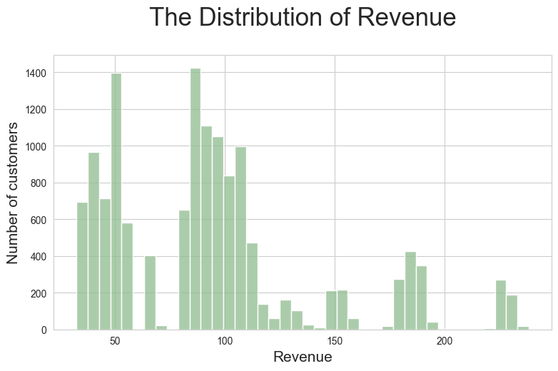

According to the boxplot provided below, the **call** method has the lowest revenue range, between `32,54$` and `71,36$`. The **email** method has an average revenue range, between `78,83$` and `148,97$`. Meanwhile, the **email and call** method has the highest revenue range, between `122,11$` and `238,32$`.

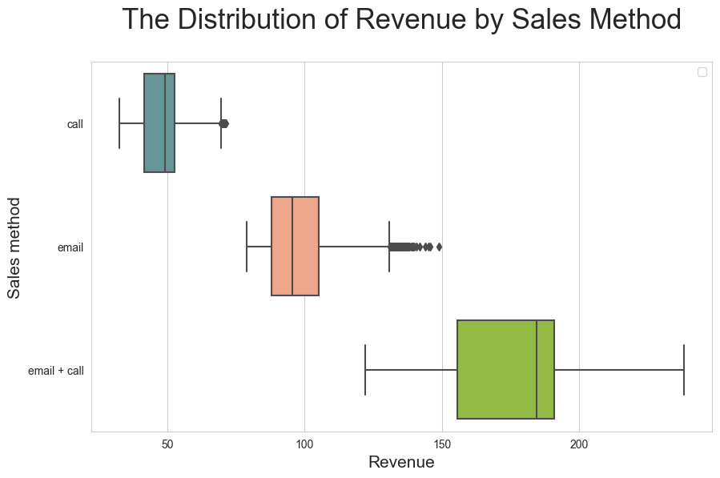

The proportion of revenue generated by each method is not consistent with the proportion of customers for each method. The email method generates the highest revenue, followed by the email and call method, while the call method generates the lowest revenue despite having the second highest number of customers.

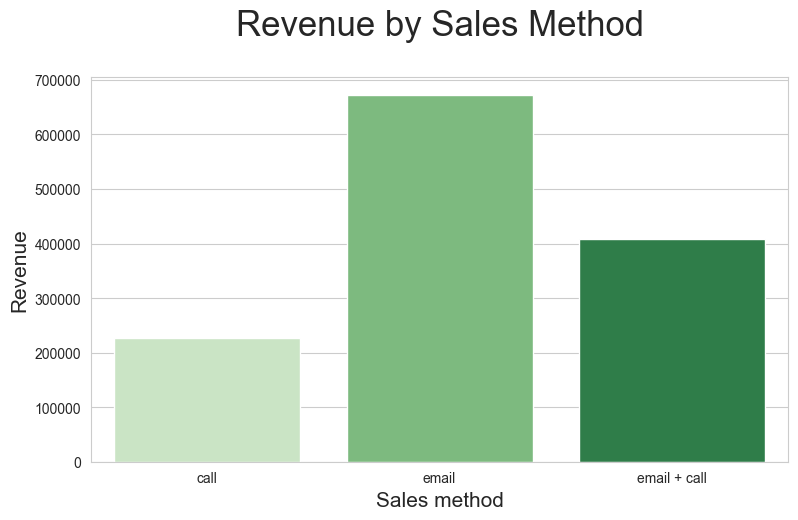

Therefore, I decided to calculate the price for each product sold and analyze its distribution. The average price for the call method is `5$`, while for the email method it is `10$`, and for the email and call method, it is `15$`. The price distribution for each method is distinct and does not overlap. However, I am uncertain whether specific products were bought using different approaches, or if different types of products were sold using different sales methods. If different types of products were sold using different sales methods, to make an objective choice of approach, it would be necessary to collect data on every type of product sold with every type of sales method.

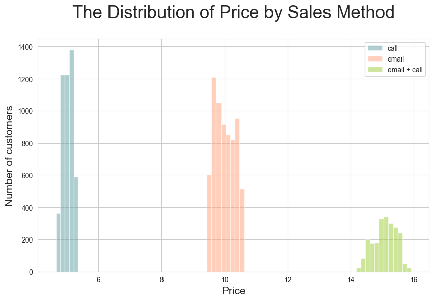

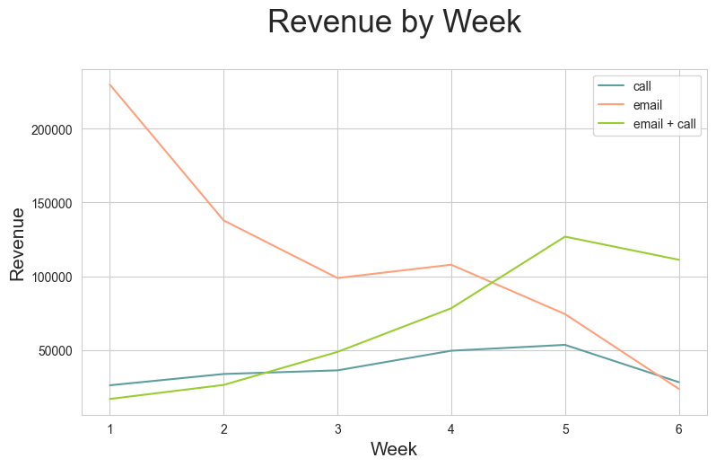

Based on the chart below, it can be observed that the revenue by number of site visits follows a normal distribution. However, the distribution for the email and call method is slightly left-skewed. This may be due to the fact that customers who are interested in purchasing more expensive products need more time to think about their purchase, which could lead to an increased number of site visits before making a purchase. The previous chart also showed a gradual increase in revenue over time, which could support this theory.

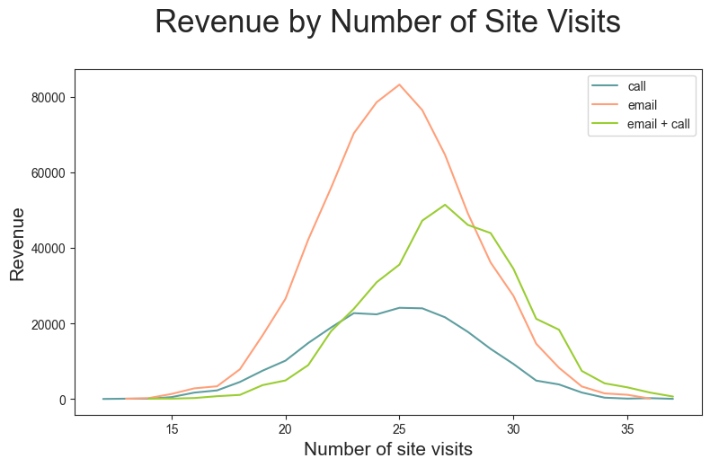

The customers who have been buying from us for 1 year are the most active and bring in the most revenue, while revenue decreases as the number of years as a customer increases for each method. Therefore, it’s important to pay attention to customers who have been with us for longer periods and find ways to keep them engaged and interested in our products.

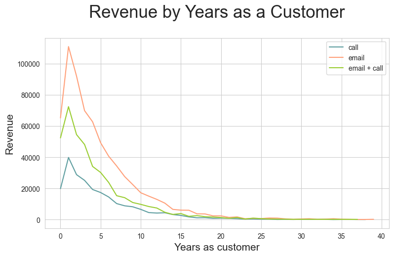

The prices for each approach are consistent across all states.

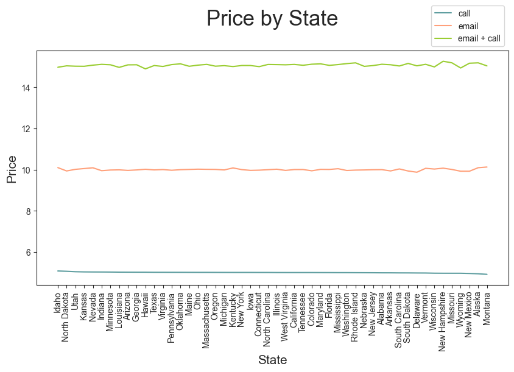

Therefore revenue for each state relies solely on the number of customers in that state. California has the highest number of customers, while Vermont has the lowest.

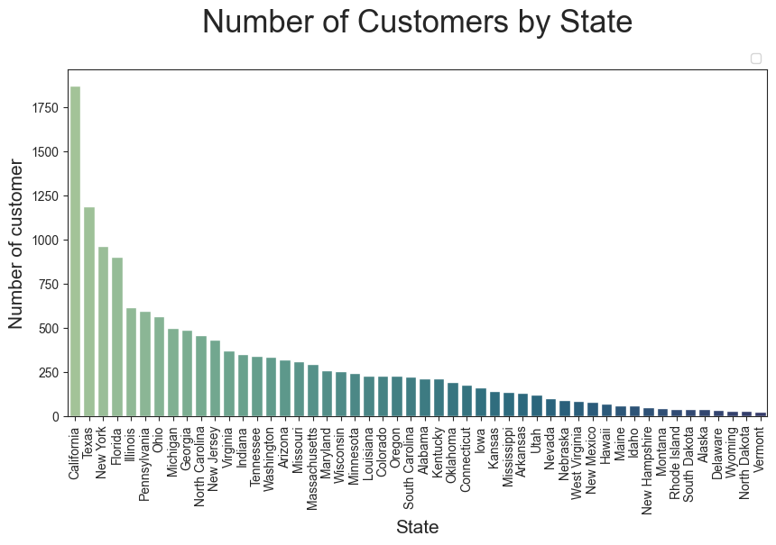

## Business Metrics

In order to determine the most effective approach, I suggest using **the ratio of the average price of products sold in the last 6 weeks to the cost of each approach** as our metric. While we don't have specific numbers for the amount of time spent on each customer for each approach, we can make some assumptions based on the information provided. It appears that the most time-consuming method is the call approach, as it takes an average of 30 minutes per customer. The email and call approach is likely the next most time-consuming, with email requiring relatively little work from the team and the call taking around 10 minutes per customer. Finally, the least time-consuming approach is likely the email method.

Based on our data, we can see that the call method, which takes the most time with an average of 30 minutes per customer, generates an average price of `5$`. On the other hand, the email method, which requires the least amount of time, generates an average price of `10$`. The email and call method, which falls somewhere in between in terms of time spent, generates an average price of `15$`. Depending on the resources available to our company, the most effective approach can be chosen based on this metric.

## Recommendation

I have recommendations for two different possibilities:

1. **Different types of products were sold using different sales methods**

   I suggest collecting data on each type of product sold using each sales method and tracking the amount of time spent on each approach. This will enable us to conduct the analysis again with more granular data.
2. **Specific products were bought using different approaches**

   The **call strategy** requires a significant amount of time and resources, it may not be the most cost-effective strategy for lower-priced products. So I would not recommend continuing to use this approach.

   If the goal is to maximize revenue while minimizing costs, it may be best to choose the **email strategy** as it generated a high revenue per item sold and required very little work from the team.

   If resources are available, the **email and call strategy** may also be effective as it generated the highest revenue per item sold.

**Other recomendations:**

1. I would suggest to pay attention to customers who have been with us for longer periods and find ways to keep them engaged and interested in our products. This could include offering special promotions or discounts, providing personalized recommendations, or improving the overall customer experience.
2. Additionally, to increase our customer base in states with fewer customers, we should focus our marketing efforts on those areas.